# Differential methylation analysis report EXP24000675_CD81_KAL_silenced_vs_miniTETv1_off_target

# Dataset overview

## Reference genome

Reference genome: `hg38_plus_PL2001_transgene_LTR`

## Sample overview

| sample | condition | 3X Tile |
| --- | --- | --- |
| XY1_SILENCE1 | KAL_silenced | 4224 |
| XY2_SILENCE2 | KAL_silenced | 4285 |
| XY5_TET6_1 | dCas9-miniTETv1 | 4346 |
| XY6_TET6_2 | dCas9-miniTETv1 | 4319 |

## Coverage Statistics

Tiles must meet coverage requirements in all samples to be included in analysis.

Tiles with at least 3X coverage in all samples:4,145

# PCA

## Tile

PCA analysis on tile % methylation matrix **X** where **X(i,j)** represents the % methylation of tile **j** in sample **i**.

Tiles are 100 bp windows with a minimum of 5 CpGs.

### Biplot

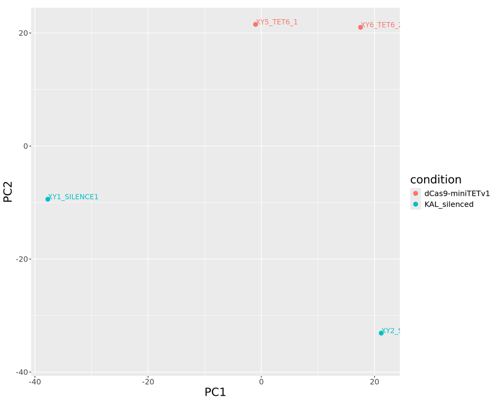

### Screeplot

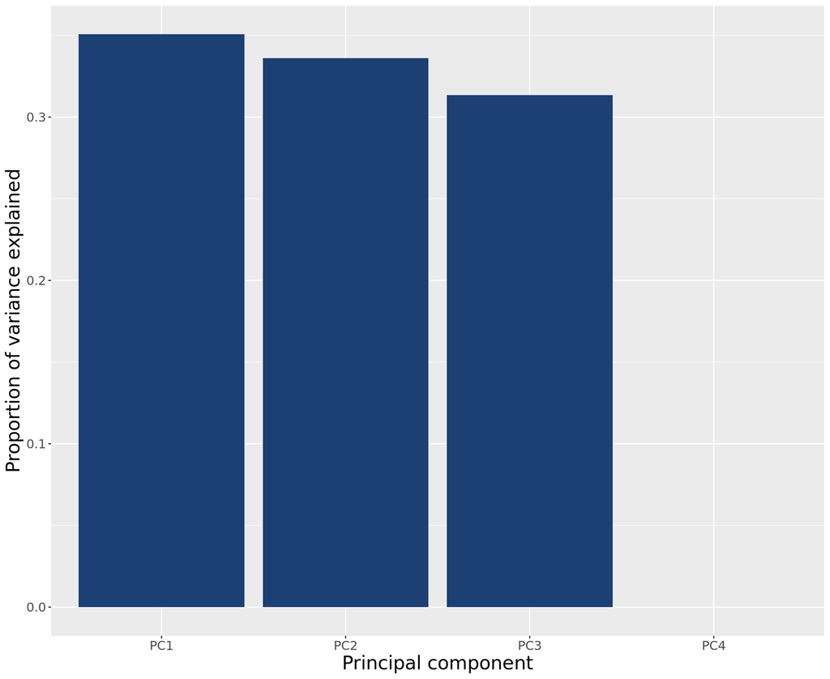

# Heatmap of the sample-to-sample distances

## Tile

Euclidean distances between samples in tile % methylation matrix.

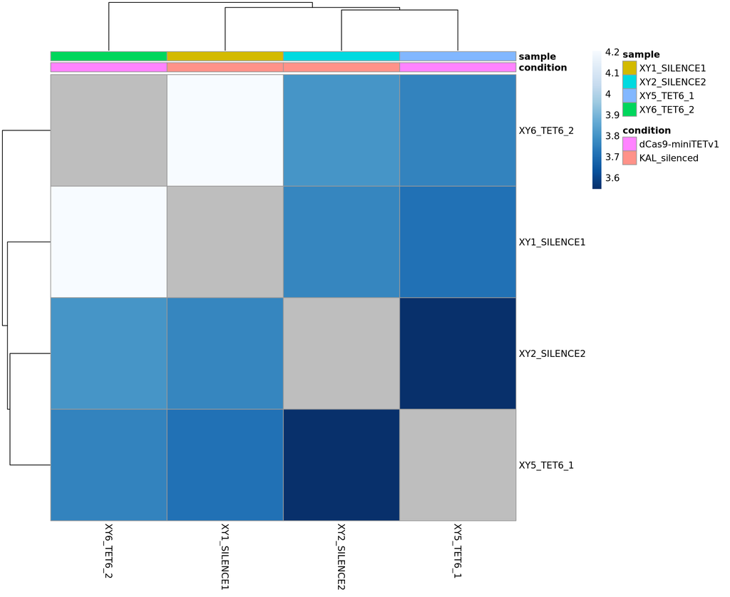

# Differentially methylated regions

## Tile % methylation scatterplot

All 4145 Tiles are plotted with average % methylation in dCas9-miniTETv1 vs KAL_silenced.

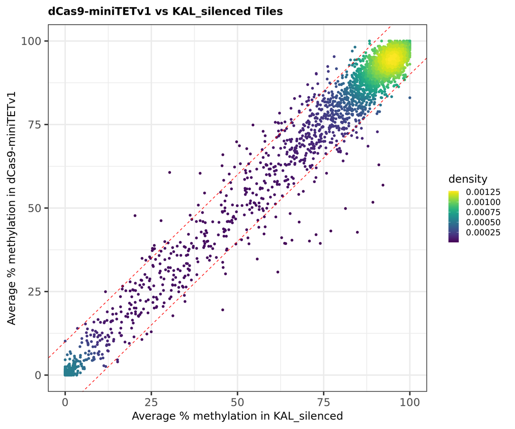

## DMR table

Differentially methylated regions are calcualted using methylKit. Depending on the sample size per each set it will either use Fisher’s exact or logistic regression to calculate P-values. P-values will be adjusted to Q-values using SLIM method (Wang, Tuominen, and Tsai 2011). Note: if we have replicates, the function will automatically use logistic regression.

Treatment : dCas9-miniTETv1  
Control : KAL_silenced

**49** DMRs were identified with q-value < 0.05 and % methylation difference > 10.

| chr | start | end | XY1_SILENCE1 | XY2_SILENCE2 | XY5_TET6_1 | XY6_TET6_2 | avg_treat | avg_ctrl | pvalue | qvalue | meth.diff |
| --- | --- | --- | --- | --- | --- | --- | --- | --- | --- | --- | --- |
| chr1 | 5967301 | 5967400 | 92.10526315789474 | 84.61538461538461 | 100 | 98.41269841269842 | 99.20634920634922 | 88.36032388663968 | 0.0007132957990397515 | 0.04585560221527595 | 10.81111870585555 |
| chr10 | 132250701 | 132250800 | 94.11764705882354 | 92.7536231884058 | 85.61643835616438 | 81.32530120481928 | 83.47086978049182 | 93.43563512361467 | 0.0007930875198902935 | 0.04851814332336352 | -10.23391812865496 |
| chr10 | 133103401 | 133103500 | 83.87096774193549 | 84.12698412698413 | 93.97590361445783 | 94.69026548672566 | 94.33308455059175 | 83.9989759344598 | 0.000564376268397799 | 0.03964146816000255 | 10.36949026185817 |
| chr11 | 2377001 | 2377100 | 91.77215189873418 | 90.2439024390244 | 70.9090909090909 | 54.96688741721854 | 62.93798916315473 | 91.0080271688793 | 1.012128056097263e-17 | 5.484185931666989e-15 | -27.70264957936944 |
| chr11 | 2377101 | 2377200 | 93.00411522633745 | 76.54867256637168 | 67.06827309236948 | 18.4331797235023 | 42.75072640793589 | 84.77639389635456 | 1.796437738700509e-40 | 3.406880661020412e-37 | -40.65402600730255 |
| chr11 | 2377201 | 2377300 | 76.7515923566879 | 71.28378378378379 | 59.55882352941177 | 19.28251121076233 | 39.42066737008705 | 74.01768807023583 | 1.648940098089568e-28 | 1.563578300082406e-25 | -32.68421924159629 |
| chr11 | 2377301 | 2377400 | 91.63424124513618 | 86.92660550458716 | 75.55555555555556 | 27.89968652037618 | 51.72762103796587 | 89.28042337486167 | 1.385162496145249e-58 | 5.253823407096374e-55 | -33.68694818972008 |
| chr11 | 2377401 | 2377500 | 81.33971291866028 | 81.32183908045977 | 69.25207756232687 | 30.47210300429185 | 49.86209028330936 | 81.33077599956002 | 1.883322598368591e-27 | 1.428661890277588e-24 | -27.29118864889099 |
| chr11 | 2377501 | 2377600 | 93.4640522875817 | 90.94488188976378 | 77.12177121771218 | 36.60130718954248 | 56.86153920362733 | 92.20446708867274 | 3.872231394213926e-31 | 4.89569996137148e-28 | -29.82142857142858 |
| chr11 | 2377601 | 2377700 | 76.3265306122449 | 77.83018867924528 | 64.91228070175438 | 21.34831460674157 | 43.13029765424798 | 77.07835964574508 | 1.72681161641848e-21 | 1.091612393880706e-18 | -31.21126214010844 |

[output cut: 39 more lines]

## Volcano plot

% methylation change = dCas9-miniTETv1 % methylation - KAL_silenced % methylation

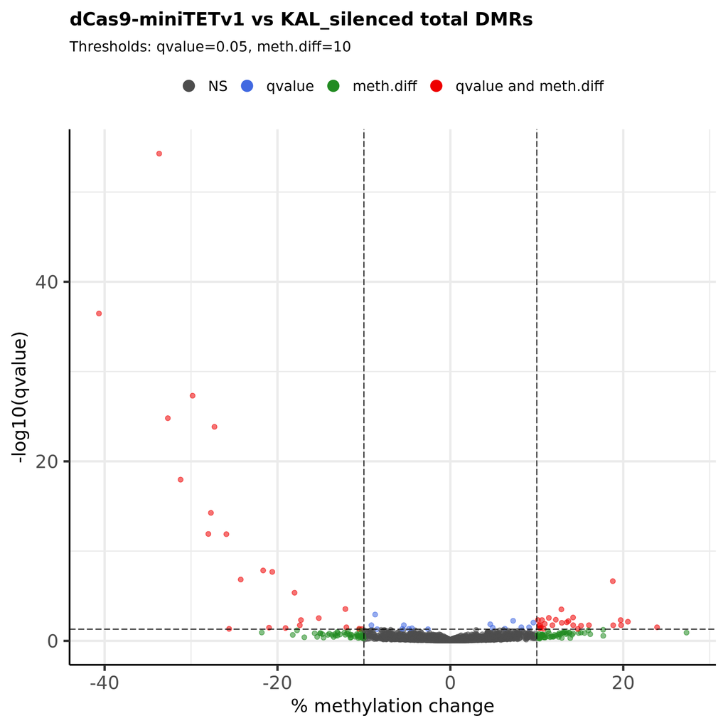